# Risk Factor Analysis

## Outcome Variable

**Outcome Variable:** haz

## Predictor Variables

**Intervention Variable:** impfloor

**Adjustment Set:**

- arm
- sex
- W_mage
- meducyrs
- feducyrs
- hhwealth_quart
- hfoodsec
- W_mhtcm
- W_mwtkg
- W_mbmi
- W_nrooms
- W_nchldlt5
- W_parity
- impsan
- safeh20
- delta_W_mage
- delta_meducyrs
- delta_feducyrs
- delta_hhwealth_quart
- delta_hfoodsec
- delta_W_mhtcm
- delta_W_mwtkg
- delta_W_mbmi
- delta_W_nrooms
- delta_W_nchldlt5
- delta_W_parity
- delta_impsan
- delta_safeh20

## Stratifying Variables

The analysis was stratified on these variable(s):

- agecat
- studyid
- country

## Data Summary

| agecat | studyid | country | impfloor | n_cell | n | outcome_variable |
| --- | --- | --- | --- | --- | --- | --- |
| Birth | CMC-V-BCS-2002 | INDIA | 1 | 72 | 72 | haz |
| Birth | CMC-V-BCS-2002 | INDIA | 0 | 0 | 72 | haz |
| Birth | CONTENT | PERU | 1 | 2 | 2 | haz |
| Birth | CONTENT | PERU | 0 | 0 | 2 | haz |
| Birth | GMS-Nepal | NEPAL | 1 | 100 | 544 | haz |
| Birth | GMS-Nepal | NEPAL | 0 | 444 | 544 | haz |
| Birth | IRC | INDIA | 1 | 287 | 287 | haz |
| Birth | IRC | INDIA | 0 | 0 | 287 | haz |
| Birth | JiVitA-3 | BANGLADESH | 1 | 1394 | 22399 | haz |
| Birth | JiVitA-3 | BANGLADESH | 0 | 21005 | 22399 | haz |
| Birth | JiVitA-4 | BANGLADESH | 1 | 307 | 2820 | haz |
| Birth | JiVitA-4 | BANGLADESH | 0 | 2513 | 2820 | haz |
| Birth | MAL-ED | BANGLADESH | 1 | 196 | 213 | haz |
| Birth | MAL-ED | BANGLADESH | 0 | 17 | 213 | haz |
| Birth | MAL-ED | BRAZIL | 1 | 58 | 60 | haz |
| Birth | MAL-ED | BRAZIL | 0 | 2 | 60 | haz |
| Birth | MAL-ED | INDIA | 1 | 35 | 41 | haz |
| Birth | MAL-ED | INDIA | 0 | 6 | 41 | haz |
| Birth | MAL-ED | NEPAL | 1 | 9 | 25 | haz |
| Birth | MAL-ED | NEPAL | 0 | 16 | 25 | haz |
| Birth | MAL-ED | PERU | 1 | 39 | 215 | haz |
| Birth | MAL-ED | PERU | 0 | 176 | 215 | haz |
| Birth | MAL-ED | SOUTH AFRICA | 1 | 87 | 96 | haz |
| Birth | MAL-ED | SOUTH AFRICA | 0 | 9 | 96 | haz |
| Birth | MAL-ED | TANZANIA, UNITED REPUBLIC OF | 1 | 7 | 119 | haz |
| Birth | MAL-ED | TANZANIA, UNITED REPUBLIC OF | 0 | 112 | 119 | haz |
| Birth | NIH-Birth | BANGLADESH | 1 | 533 | 605 | haz |
| Birth | NIH-Birth | BANGLADESH | 0 | 72 | 605 | haz |
| Birth | NIH-Crypto | BANGLADESH | 1 | 558 | 732 | haz |
| Birth | NIH-Crypto | BANGLADESH | 0 | 174 | 732 | haz |

[output cut: 66 more lines]

The following strata were considered:

- agecat: 24 months, studyid: CMC-V-BCS-2002, country: INDIA
- agecat: 24 months, studyid: CONTENT, country: PERU
- agecat: 24 months, studyid: GMS-Nepal, country: NEPAL
- agecat: 24 months, studyid: IRC, country: INDIA
- agecat: 24 months, studyid: JiVitA-3, country: BANGLADESH
- agecat: 24 months, studyid: JiVitA-4, country: BANGLADESH
- agecat: 24 months, studyid: MAL-ED, country: BANGLADESH
- agecat: 24 months, studyid: MAL-ED, country: BRAZIL
- agecat: 24 months, studyid: MAL-ED, country: INDIA
- agecat: 24 months, studyid: MAL-ED, country: NEPAL
- agecat: 24 months, studyid: MAL-ED, country: PERU
- agecat: 24 months, studyid: MAL-ED, country: SOUTH AFRICA
- agecat: 24 months, studyid: MAL-ED, country: TANZANIA, UNITED REPUBLIC OF
- agecat: 24 months, studyid: NIH-Birth, country: BANGLADESH
- agecat: 24 months, studyid: NIH-Crypto, country: BANGLADESH
- agecat: 24 months, studyid: PROVIDE, country: BANGLADESH
- agecat: 6 months, studyid: CMC-V-BCS-2002, country: INDIA
- agecat: 6 months, studyid: CONTENT, country: PERU
- agecat: 6 months, studyid: GMS-Nepal, country: NEPAL
- agecat: 6 months, studyid: IRC, country: INDIA
- agecat: 6 months, studyid: JiVitA-3, country: BANGLADESH
- agecat: 6 months, studyid: JiVitA-4, country: BANGLADESH
- agecat: 6 months, studyid: MAL-ED, country: BANGLADESH
- agecat: 6 months, studyid: MAL-ED, country: BRAZIL
- agecat: 6 months, studyid: MAL-ED, country: INDIA
- agecat: 6 months, studyid: MAL-ED, country: NEPAL
- agecat: 6 months, studyid: MAL-ED, country: PERU
- agecat: 6 months, studyid: MAL-ED, country: SOUTH AFRICA
- agecat: 6 months, studyid: MAL-ED, country: TANZANIA, UNITED REPUBLIC OF
- agecat: 6 months, studyid: NIH-Birth, country: BANGLADESH
- agecat: 6 months, studyid: NIH-Crypto, country: BANGLADESH
- agecat: 6 months, studyid: PROVIDE, country: BANGLADESH
- agecat: Birth, studyid: CMC-V-BCS-2002, country: INDIA
- agecat: Birth, studyid: CONTENT, country: PERU
- agecat: Birth, studyid: GMS-Nepal, country: NEPAL
- agecat: Birth, studyid: IRC, country: INDIA
- agecat: Birth, studyid: JiVitA-3, country: BANGLADESH
- agecat: Birth, studyid: JiVitA-4, country: BANGLADESH
- agecat: Birth, studyid: MAL-ED, country: BANGLADESH
- agecat: Birth, studyid: MAL-ED, country: BRAZIL
- agecat: Birth, studyid: MAL-ED, country: INDIA
- agecat: Birth, studyid: MAL-ED, country: NEPAL
- agecat: Birth, studyid: MAL-ED, country: PERU
- agecat: Birth, studyid: MAL-ED, country: SOUTH AFRICA
- agecat: Birth, studyid: MAL-ED, country: TANZANIA, UNITED REPUBLIC OF
- agecat: Birth, studyid: NIH-Birth, country: BANGLADESH
- agecat: Birth, studyid: NIH-Crypto, country: BANGLADESH
- agecat: Birth, studyid: PROVIDE, country: BANGLADESH

### Dropped Strata

- agecat: Birth, studyid: CMC-V-BCS-2002, country: INDIA
- agecat: Birth, studyid: CONTENT, country: PERU
- agecat: Birth, studyid: IRC, country: INDIA
- agecat: Birth, studyid: MAL-ED, country: BRAZIL
- agecat: 6 months, studyid: CMC-V-BCS-2002, country: INDIA
- agecat: 6 months, studyid: IRC, country: INDIA
- agecat: 6 months, studyid: MAL-ED, country: BRAZIL
- agecat: 24 months, studyid: CMC-V-BCS-2002, country: INDIA
- agecat: 24 months, studyid: IRC, country: INDIA
- agecat: 24 months, studyid: MAL-ED, country: BRAZIL

## Methods Detail

We’re interested in the causal parameters $E[Y_a]$ for all values of $a \in \mathcal{A}$. These parameters represent the mean outcome if, possibly contrary to fact, we intervened to set all units to have $A=a$. Under the randomization and positivity assumptions, these are identified by the statistical parameters $\psi_a=E_W[E_{Y|A,W}(Y|A=a,W)]$. In addition, we’re interested in the mean of $Y$, $E[Y]$ under no intervention (the observed mean). We will estimate these parameters by using SuperLearner to fit the relevant likelihood factors – $E_{Y|A,W}(Y|A=a,W)$ and $p(A=a|W)$, and then updating our likelihood fit using a joint TMLE.

For unadjusted analyses ($W=\{\}$), initial likelihoods were estimated using Lrnr_glm to estimate the simple $E(Y|A)$ and Lrnr_mean to estimate $p(A)$. For adjusted analyses, a small library containing Lrnr_glmnet, Lrnr_xgboost, and Lrnr_mean was used.

# Results Detail

## Results Plots

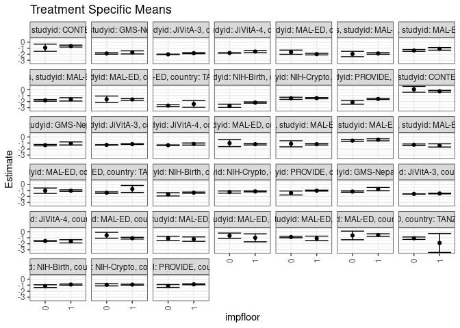

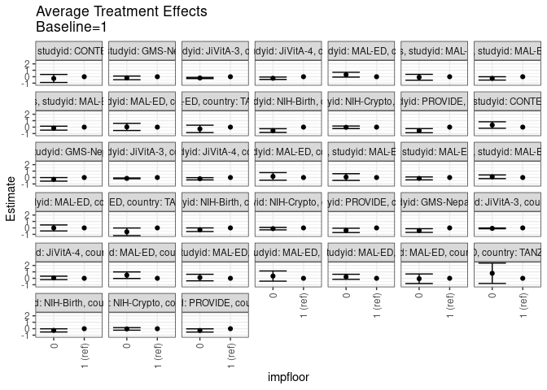

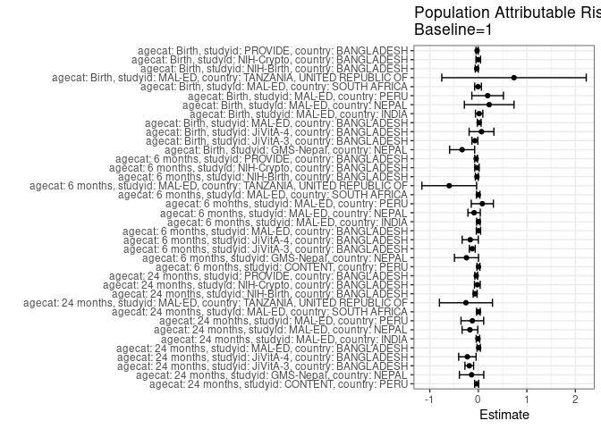

## Results Table

### Parameter: TSM

| agecat | studyid | country | intervention_level | baseline_level | estimate | ci_lower | ci_upper |
| --- | --- | --- | --- | --- | --- | --- | --- |
| Birth | GMS-Nepal | NEPAL | 1 | NA | -0.7843600 | -1.0485412 | -0.5201789 |
| Birth | GMS-Nepal | NEPAL | 0 | NA | -1.1950032 | -1.3084886 | -1.0815177 |
| Birth | JiVitA-3 | BANGLADESH | 1 | NA | -1.5187040 | -1.5811840 | -1.4562241 |
| Birth | JiVitA-3 | BANGLADESH | 0 | NA | -1.5885025 | -1.6083622 | -1.5686429 |
| Birth | JiVitA-4 | BANGLADESH | 1 | NA | -1.5891576 | -1.8551375 | -1.3231778 |
| Birth | JiVitA-4 | BANGLADESH | 0 | NA | -1.5308659 | -1.5840673 | -1.4776644 |
| Birth | MAL-ED | BANGLADESH | 1 | NA | -1.0701988 | -1.2130125 | -0.9273851 |
| Birth | MAL-ED | BANGLADESH | 0 | NA | -0.5866135 | -1.0742195 | -0.0990075 |
| Birth | MAL-ED | INDIA | 1 | NA | -1.2242857 | -1.5919558 | -0.8566156 |
| Birth | MAL-ED | INDIA | 0 | NA | -1.1066667 | -1.4622060 | -0.7511274 |
| Birth | MAL-ED | NEPAL | 1 | NA | -1.0066667 | -1.6704675 | -0.3428658 |
| Birth | MAL-ED | NEPAL | 0 | NA | -0.6568750 | -1.0897018 | -0.2240482 |
| Birth | MAL-ED | PERU | 1 | NA | -1.1060960 | -1.4820666 | -0.7301253 |
| Birth | MAL-ED | PERU | 0 | NA | -0.8759643 | -0.9989769 | -0.7529517 |
| Birth | MAL-ED | SOUTH AFRICA | 1 | NA | -0.5463218 | -0.7573107 | -0.3353330 |
| Birth | MAL-ED | SOUTH AFRICA | 0 | NA | -0.6111111 | -1.3247632 | 0.1025410 |
| Birth | MAL-ED | TANZANIA, UNITED REPUBLIC OF | 1 | NA | -1.8571429 | -3.4252117 | -0.2890740 |
| Birth | MAL-ED | TANZANIA, UNITED REPUBLIC OF | 0 | NA | -1.0753571 | -1.2760805 | -0.8746338 |
| Birth | NIH-Birth | BANGLADESH | 1 | NA | -0.8961671 | -0.9914491 | -0.8008850 |
| Birth | NIH-Birth | BANGLADESH | 0 | NA | -1.1603679 | -1.3870505 | -0.9336852 |
| Birth | NIH-Crypto | BANGLADESH | 1 | NA | -0.9085428 | -0.9881035 | -0.8289820 |
| Birth | NIH-Crypto | BANGLADESH | 0 | NA | -0.9399088 | -1.1221029 | -0.7577147 |
| Birth | PROVIDE | BANGLADESH | 1 | NA | -0.8600817 | -0.9392469 | -0.7809165 |
| Birth | PROVIDE | BANGLADESH | 0 | NA | -1.1344776 | -1.3719913 | -0.8969638 |
| 6 months | CONTENT | PERU | 1 | NA | -0.2805426 | -0.4182026 | -0.1428826 |
| 6 months | CONTENT | PERU | 0 | NA | 0.0402121 | -0.4449064 | 0.5253306 |
| 6 months | GMS-Nepal | NEPAL | 1 | NA | -1.0790309 | -1.3335813 | -0.8244804 |
| 6 months | GMS-Nepal | NEPAL | 0 | NA | -1.3650680 | -1.4727480 | -1.2573880 |
| 6 months | JiVitA-3 | BANGLADESH | 1 | NA | -1.1887948 | -1.2495302 | -1.1280594 |
| 6 months | JiVitA-3 | BANGLADESH | 0 | NA | -1.3211469 | -1.3461650 | -1.2961289 |
| 6 months | JiVitA-4 | BANGLADESH | 1 | NA | -1.1771417 | -1.3490172 | -1.0052663 |
| 6 months | JiVitA-4 | BANGLADESH | 0 | NA | -1.3698885 | -1.4106700 | -1.3291070 |
| 6 months | MAL-ED | BANGLADESH | 1 | NA | -1.2055060 | -1.3243639 | -1.0866481 |
| 6 months | MAL-ED | BANGLADESH | 0 | NA | -1.0327531 | -1.6082788 | -0.4572274 |
| 6 months | MAL-ED | INDIA | 1 | NA | -1.2086494 | -1.3302955 | -1.0870032 |
| 6 months | MAL-ED | INDIA | 0 | NA | -1.1358337 | -1.6404219 | -0.6312455 |
| 6 months | MAL-ED | NEPAL | 1 | NA | -0.4665038 | -0.6416387 | -0.2913688 |
| 6 months | MAL-ED | NEPAL | 0 | NA | -0.6040625 | -0.7515301 | -0.4565949 |
| 6 months | MAL-ED | PERU | 1 | NA | -1.4073343 | -1.6711255 | -1.1435432 |
| 6 months | MAL-ED | PERU | 0 | NA | -1.2935919 | -1.4120119 | -1.1751719 |
| 6 months | MAL-ED | SOUTH AFRICA | 1 | NA | -1.0529241 | -1.1894984 | -0.9163498 |
| 6 months | MAL-ED | SOUTH AFRICA | 0 | NA | -1.0580976 | -1.5022761 | -0.6139192 |
| 6 months | MAL-ED | TANZANIA, UNITED REPUBLIC OF | 1 | NA | -0.7706625 | -1.3484754 | -0.1928496 |
| 6 months | MAL-ED | TANZANIA, UNITED REPUBLIC OF | 0 | NA | -1.3801113 | -1.5068686 | -1.2533541 |
| 6 months | NIH-Birth | BANGLADESH | 1 | NA | -1.3768549 | -1.4718742 | -1.2818357 |
| 6 months | NIH-Birth | BANGLADESH | 0 | NA | -1.6595711 | -1.9270409 | -1.3921014 |
| 6 months | NIH-Crypto | BANGLADESH | 1 | NA | -1.1705346 | -1.2514627 | -1.0896065 |
| 6 months | NIH-Crypto | BANGLADESH | 0 | NA | -1.2828201 | -1.4588834 | -1.1067568 |
| 6 months | PROVIDE | BANGLADESH | 1 | NA | -1.0463951 | -1.1213167 | -0.9714734 |
| 6 months | PROVIDE | BANGLADESH | 0 | NA | -1.4347883 | -1.7612681 | -1.1083084 |
| 24 months | CONTENT | PERU | 1 | NA | -0.6529957 | -0.8093284 | -0.4966631 |
| 24 months | CONTENT | PERU | 0 | NA | -0.9223470 | -1.5221336 | -0.3225603 |
| 24 months | GMS-Nepal | NEPAL | 1 | NA | -1.7009508 | -1.9603018 | -1.4415998 |
| 24 months | GMS-Nepal | NEPAL | 0 | NA | -1.8794002 | -1.9943625 | -1.7644380 |
| 24 months | JiVitA-3 | BANGLADESH | 1 | NA | -1.8270189 | -1.9162489 | -1.7377889 |
| 24 months | JiVitA-3 | BANGLADESH | 0 | NA | -2.0224749 | -2.0521303 | -1.9928196 |
| 24 months | JiVitA-4 | BANGLADESH | 1 | NA | -1.5548511 | -1.7400133 | -1.3696890 |
| 24 months | JiVitA-4 | BANGLADESH | 0 | NA | -1.7919920 | -1.8302795 | -1.7537045 |
| 24 months | MAL-ED | BANGLADESH | 1 | NA | -1.9856072 | -2.1187735 | -1.8524409 |
| 24 months | MAL-ED | BANGLADESH | 0 | NA | -1.6693970 | -2.0191237 | -1.3196703 |
| 24 months | MAL-ED | INDIA | 1 | NA | -1.8785962 | -2.0064419 | -1.7507504 |
| 24 months | MAL-ED | INDIA | 0 | NA | -1.9633107 | -2.4008994 | -1.5257220 |
| 24 months | MAL-ED | NEPAL | 1 | NA | -1.1194880 | -1.3296799 | -0.9092960 |
| 24 months | MAL-ED | NEPAL | 0 | NA | -1.3839790 | -1.5337646 | -1.2341933 |
| 24 months | MAL-ED | PERU | 1 | NA | -1.6291483 | -1.9029871 | -1.3553095 |
| 24 months | MAL-ED | PERU | 0 | NA | -1.7918127 | -1.9282707 | -1.6553548 |
| 24 months | MAL-ED | SOUTH AFRICA | 1 | NA | -1.6466691 | -1.7876436 | -1.5056947 |
| 24 months | MAL-ED | SOUTH AFRICA | 0 | NA | -1.6166211 | -2.1526691 | -1.0805731 |
| 24 months | MAL-ED | TANZANIA, UNITED REPUBLIC OF | 1 | NA | -2.3882369 | -2.9436519 | -1.8328219 |
| 24 months | MAL-ED | TANZANIA, UNITED REPUBLIC OF | 0 | NA | -2.6642705 | -2.8051469 | -2.5233942 |
| 24 months | NIH-Birth | BANGLADESH | 1 | NA | -2.1577876 | -2.2657408 | -2.0498344 |
| 24 months | NIH-Birth | BANGLADESH | 0 | NA | -2.6950487 | -2.9655051 | -2.4245923 |
| 24 months | NIH-Crypto | BANGLADESH | 1 | NA | -1.4213597 | -1.5214021 | -1.3213173 |
| 24 months | NIH-Crypto | BANGLADESH | 0 | NA | -1.4515269 | -1.6255576 | -1.2774962 |
| 24 months | PROVIDE | BANGLADESH | 1 | NA | -1.5590565 | -1.6443671 | -1.4737459 |
| 24 months | PROVIDE | BANGLADESH | 0 | NA | -2.1119139 | -2.4208979 | -1.8029300 |

### Parameter: E(Y)

| agecat | studyid | country | intervention_level | baseline_level | estimate | ci_lower | ci_upper |
| --- | --- | --- | --- | --- | --- | --- | --- |
| Birth | GMS-Nepal | NEPAL | NA | NA | -1.1177022 | -1.2075344 | -1.0278700 |
| Birth | JiVitA-3 | BANGLADESH | NA | NA | -1.5895451 | -1.6088186 | -1.5702715 |
| Birth | JiVitA-4 | BANGLADESH | NA | NA | -1.5236135 | -1.5727559 | -1.4744711 |
| Birth | MAL-ED | BANGLADESH | NA | NA | -1.0530516 | -1.1896058 | -0.9164975 |
| Birth | MAL-ED | INDIA | NA | NA | -1.2070732 | -1.5254820 | -0.8886644 |
| Birth | MAL-ED | NEPAL | NA | NA | -0.7828000 | -1.1547571 | -0.4108429 |
| Birth | MAL-ED | PERU | NA | NA | -0.9141395 | -1.0364098 | -0.7918693 |
| Birth | MAL-ED | SOUTH AFRICA | NA | NA | -0.5523958 | -0.7550074 | -0.3497843 |
| Birth | MAL-ED | TANZANIA, UNITED REPUBLIC OF | NA | NA | -1.1213445 | -1.3341800 | -0.9085090 |
| Birth | NIH-Birth | BANGLADESH | NA | NA | -0.9289256 | -1.0178691 | -0.8399821 |
| Birth | NIH-Crypto | BANGLADESH | NA | NA | -0.9094945 | -0.9809370 | -0.8380521 |
| Birth | PROVIDE | BANGLADESH | NA | NA | -0.8851020 | -0.9601332 | -0.8100709 |
| 6 months | CONTENT | PERU | NA | NA | -0.2785256 | -0.4098735 | -0.1471776 |
| 6 months | GMS-Nepal | NEPAL | NA | NA | -1.3225094 | -1.4115793 | -1.2334396 |
| 6 months | JiVitA-3 | BANGLADESH | NA | NA | -1.3134597 | -1.3365976 | -1.2903219 |
| 6 months | JiVitA-4 | BANGLADESH | NA | NA | -1.3440174 | -1.3812821 | -1.3067527 |
| 6 months | MAL-ED | BANGLADESH | NA | NA | -1.2026806 | -1.3203025 | -1.0850586 |
| 6 months | MAL-ED | INDIA | NA | NA | -1.2070638 | -1.3255909 | -1.0885368 |
| 6 months | MAL-ED | NEPAL | NA | NA | -0.5534862 | -0.6681825 | -0.4387899 |
| 6 months | MAL-ED | PERU | NA | NA | -1.3248549 | -1.4336721 | -1.2160378 |
| 6 months | MAL-ED | SOUTH AFRICA | NA | NA | -1.0547925 | -1.1843544 | -0.9252306 |
| 6 months | MAL-ED | TANZANIA, UNITED REPUBLIC OF | NA | NA | -1.3700408 | -1.4930436 | -1.2470380 |
| 6 months | NIH-Birth | BANGLADESH | NA | NA | -1.4060639 | -1.4948910 | -1.3172368 |
| 6 months | NIH-Crypto | BANGLADESH | NA | NA | -1.1986783 | -1.2700937 | -1.1272630 |
| 6 months | PROVIDE | BANGLADESH | NA | NA | -1.0916915 | -1.1661176 | -1.0172654 |
| 24 months | CONTENT | PERU | NA | NA | -0.6868598 | -0.8388476 | -0.5348719 |
| 24 months | GMS-Nepal | NEPAL | NA | NA | -1.8396747 | -1.9349390 | -1.7444104 |
| 24 months | JiVitA-3 | BANGLADESH | NA | NA | -2.0134592 | -2.0410825 | -1.9858359 |
| 24 months | JiVitA-4 | BANGLADESH | NA | NA | -1.7804046 | -1.8159135 | -1.7448956 |
| 24 months | MAL-ED | BANGLADESH | NA | NA | -1.9783962 | -2.1050210 | -1.8517715 |
| 24 months | MAL-ED | INDIA | NA | NA | -1.8861894 | -2.0110006 | -1.7613783 |
| 24 months | MAL-ED | NEPAL | NA | NA | -1.2928054 | -1.4146944 | -1.1709164 |
| 24 months | MAL-ED | PERU | NA | NA | -1.7524710 | -1.8736426 | -1.6312994 |
| 24 months | MAL-ED | SOUTH AFRICA | NA | NA | -1.6450595 | -1.7797240 | -1.5103950 |
| 24 months | MAL-ED | TANZANIA, UNITED REPUBLIC OF | NA | NA | -2.6432311 | -2.7795797 | -2.5068826 |
| 24 months | NIH-Birth | BANGLADESH | NA | NA | -2.2235968 | -2.3265592 | -2.1206344 |
| 24 months | NIH-Crypto | BANGLADESH | NA | NA | -1.4412646 | -1.5249156 | -1.3576135 |
| 24 months | PROVIDE | BANGLADESH | NA | NA | -1.6024221 | -1.6857420 | -1.5191023 |

### Parameter: ATE

| agecat | studyid | country | intervention_level | baseline_level | estimate | ci_lower | ci_upper |
| --- | --- | --- | --- | --- | --- | --- | --- |
| Birth | GMS-Nepal | NEPAL | 1 | 1 | 0.0000000 | 0.0000000 | 0.0000000 |
| Birth | GMS-Nepal | NEPAL | 0 | 1 | -0.4106431 | -0.6974628 | -0.1238235 |
| Birth | JiVitA-3 | BANGLADESH | 1 | 1 | 0.0000000 | 0.0000000 | 0.0000000 |
| Birth | JiVitA-3 | BANGLADESH | 0 | 1 | -0.0697985 | -0.1335895 | -0.0060075 |
| Birth | JiVitA-4 | BANGLADESH | 1 | 1 | 0.0000000 | 0.0000000 | 0.0000000 |
| Birth | JiVitA-4 | BANGLADESH | 0 | 1 | 0.0582917 | -0.2099748 | 0.3265582 |
| Birth | MAL-ED | BANGLADESH | 1 | 1 | 0.0000000 | 0.0000000 | 0.0000000 |
| Birth | MAL-ED | BANGLADESH | 0 | 1 | 0.4835853 | -0.0264217 | 0.9935922 |
| Birth | MAL-ED | INDIA | 1 | 1 | 0.0000000 | 0.0000000 | 0.0000000 |
| Birth | MAL-ED | INDIA | 0 | 1 | 0.1176190 | -0.3938392 | 0.6290772 |
| Birth | MAL-ED | NEPAL | 1 | 1 | 0.0000000 | 0.0000000 | 0.0000000 |
| Birth | MAL-ED | NEPAL | 0 | 1 | 0.3497917 | -0.4426543 | 1.1422376 |
| Birth | MAL-ED | PERU | 1 | 1 | 0.0000000 | 0.0000000 | 0.0000000 |
| Birth | MAL-ED | PERU | 0 | 1 | 0.2301317 | -0.1645682 | 0.6248315 |
| Birth | MAL-ED | SOUTH AFRICA | 1 | 1 | 0.0000000 | 0.0000000 | 0.0000000 |
| Birth | MAL-ED | SOUTH AFRICA | 0 | 1 | -0.0647893 | -0.8089772 | 0.6793986 |
| Birth | MAL-ED | TANZANIA, UNITED REPUBLIC OF | 1 | 1 | 0.0000000 | 0.0000000 | 0.0000000 |
| Birth | MAL-ED | TANZANIA, UNITED REPUBLIC OF | 0 | 1 | 0.7817857 | -0.7990779 | 2.3626493 |
| Birth | NIH-Birth | BANGLADESH | 1 | 1 | 0.0000000 | 0.0000000 | 0.0000000 |
| Birth | NIH-Birth | BANGLADESH | 0 | 1 | -0.2642008 | -0.5099238 | -0.0184778 |
| Birth | NIH-Crypto | BANGLADESH | 1 | 1 | 0.0000000 | 0.0000000 | 0.0000000 |
| Birth | NIH-Crypto | BANGLADESH | 0 | 1 | -0.0313660 | -0.2298174 | 0.1670854 |
| Birth | PROVIDE | BANGLADESH | 1 | 1 | 0.0000000 | 0.0000000 | 0.0000000 |
| Birth | PROVIDE | BANGLADESH | 0 | 1 | -0.2743959 | -0.5246779 | -0.0241138 |
| 6 months | CONTENT | PERU | 1 | 1 | 0.0000000 | 0.0000000 | 0.0000000 |
| 6 months | CONTENT | PERU | 0 | 1 | 0.3207547 | -0.1846257 | 0.8261351 |
| 6 months | GMS-Nepal | NEPAL | 1 | 1 | 0.0000000 | 0.0000000 | 0.0000000 |
| 6 months | GMS-Nepal | NEPAL | 0 | 1 | -0.2860371 | -0.5624645 | -0.0096097 |
| 6 months | JiVitA-3 | BANGLADESH | 1 | 1 | 0.0000000 | 0.0000000 | 0.0000000 |
| 6 months | JiVitA-3 | BANGLADESH | 0 | 1 | -0.1323521 | -0.1965605 | -0.0681438 |
| 6 months | JiVitA-4 | BANGLADESH | 1 | 1 | 0.0000000 | 0.0000000 | 0.0000000 |
| 6 months | JiVitA-4 | BANGLADESH | 0 | 1 | -0.1927468 | -0.3683152 | -0.0171783 |
| 6 months | MAL-ED | BANGLADESH | 1 | 1 | 0.0000000 | 0.0000000 | 0.0000000 |
| 6 months | MAL-ED | BANGLADESH | 0 | 1 | 0.1727530 | -0.4151983 | 0.7607043 |
| 6 months | MAL-ED | INDIA | 1 | 1 | 0.0000000 | 0.0000000 | 0.0000000 |
| 6 months | MAL-ED | INDIA | 0 | 1 | 0.0728156 | -0.4459068 | 0.5915381 |
| 6 months | MAL-ED | NEPAL | 1 | 1 | 0.0000000 | 0.0000000 | 0.0000000 |
| 6 months | MAL-ED | NEPAL | 0 | 1 | -0.1375587 | -0.3671481 | 0.0920306 |
| 6 months | MAL-ED | PERU | 1 | 1 | 0.0000000 | 0.0000000 | 0.0000000 |
| 6 months | MAL-ED | PERU | 0 | 1 | 0.1137424 | -0.1758112 | 0.4032961 |
| 6 months | MAL-ED | SOUTH AFRICA | 1 | 1 | 0.0000000 | 0.0000000 | 0.0000000 |
| 6 months | MAL-ED | SOUTH AFRICA | 0 | 1 | -0.0051736 | -0.4701122 | 0.4597651 |
| 6 months | MAL-ED | TANZANIA, UNITED REPUBLIC OF | 1 | 1 | 0.0000000 | 0.0000000 | 0.0000000 |
| 6 months | MAL-ED | TANZANIA, UNITED REPUBLIC OF | 0 | 1 | -0.6094488 | -1.2003558 | -0.0185418 |
| 6 months | NIH-Birth | BANGLADESH | 1 | 1 | 0.0000000 | 0.0000000 | 0.0000000 |
| 6 months | NIH-Birth | BANGLADESH | 0 | 1 | -0.2827162 | -0.5662657 | 0.0008334 |
| 6 months | NIH-Crypto | BANGLADESH | 1 | 1 | 0.0000000 | 0.0000000 | 0.0000000 |
| 6 months | NIH-Crypto | BANGLADESH | 0 | 1 | -0.1122855 | -0.3049045 | 0.0803336 |
| 6 months | PROVIDE | BANGLADESH | 1 | 1 | 0.0000000 | 0.0000000 | 0.0000000 |
| 6 months | PROVIDE | BANGLADESH | 0 | 1 | -0.3883932 | -0.7234181 | -0.0533683 |
| 24 months | CONTENT | PERU | 1 | 1 | 0.0000000 | 0.0000000 | 0.0000000 |
| 24 months | CONTENT | PERU | 0 | 1 | -0.2693512 | -0.8922656 | 0.3535631 |
| 24 months | GMS-Nepal | NEPAL | 1 | 1 | 0.0000000 | 0.0000000 | 0.0000000 |
| 24 months | GMS-Nepal | NEPAL | 0 | 1 | -0.1784494 | -0.4621192 | 0.1052203 |
| 24 months | JiVitA-3 | BANGLADESH | 1 | 1 | 0.0000000 | 0.0000000 | 0.0000000 |
| 24 months | JiVitA-3 | BANGLADESH | 0 | 1 | -0.1954560 | -0.2886501 | -0.1022620 |
| 24 months | JiVitA-4 | BANGLADESH | 1 | 1 | 0.0000000 | 0.0000000 | 0.0000000 |
| 24 months | JiVitA-4 | BANGLADESH | 0 | 1 | -0.2371409 | -0.4249206 | -0.0493612 |
| 24 months | MAL-ED | BANGLADESH | 1 | 1 | 0.0000000 | 0.0000000 | 0.0000000 |
| 24 months | MAL-ED | BANGLADESH | 0 | 1 | 0.3162102 | -0.0562402 | 0.6886606 |
| 24 months | MAL-ED | INDIA | 1 | 1 | 0.0000000 | 0.0000000 | 0.0000000 |
| 24 months | MAL-ED | INDIA | 0 | 1 | -0.0847145 | -0.5404623 | 0.3710333 |
| 24 months | MAL-ED | NEPAL | 1 | 1 | 0.0000000 | 0.0000000 | 0.0000000 |
| 24 months | MAL-ED | NEPAL | 0 | 1 | -0.2644910 | -0.5250871 | -0.0038950 |
| 24 months | MAL-ED | PERU | 1 | 1 | 0.0000000 | 0.0000000 | 0.0000000 |
| 24 months | MAL-ED | PERU | 0 | 1 | -0.1626644 | -0.4683656 | 0.1430367 |
| 24 months | MAL-ED | SOUTH AFRICA | 1 | 1 | 0.0000000 | 0.0000000 | 0.0000000 |
| 24 months | MAL-ED | SOUTH AFRICA | 0 | 1 | 0.0300480 | -0.5251644 | 0.5852604 |
| 24 months | MAL-ED | TANZANIA, UNITED REPUBLIC OF | 1 | 1 | 0.0000000 | 0.0000000 | 0.0000000 |
| 24 months | MAL-ED | TANZANIA, UNITED REPUBLIC OF | 0 | 1 | -0.2760337 | -0.8491379 | 0.2970706 |
| 24 months | NIH-Birth | BANGLADESH | 1 | 1 | 0.0000000 | 0.0000000 | 0.0000000 |
| 24 months | NIH-Birth | BANGLADESH | 0 | 1 | -0.5372611 | -0.8268304 | -0.2476918 |
| 24 months | NIH-Crypto | BANGLADESH | 1 | 1 | 0.0000000 | 0.0000000 | 0.0000000 |
| 24 months | NIH-Crypto | BANGLADESH | 0 | 1 | -0.0301672 | -0.2296137 | 0.1692793 |
| 24 months | PROVIDE | BANGLADESH | 1 | 1 | 0.0000000 | 0.0000000 | 0.0000000 |
| 24 months | PROVIDE | BANGLADESH | 0 | 1 | -0.5528574 | -0.8740715 | -0.2316434 |

### Parameter: PAR

| agecat | studyid | country | intervention_level | baseline_level | estimate | ci_lower | ci_upper |
| --- | --- | --- | --- | --- | --- | --- | --- |
| Birth | GMS-Nepal | NEPAL | 1 | NA | -0.3333422 | -0.5912779 | -0.0754064 |
| Birth | JiVitA-3 | BANGLADESH | 1 | NA | -0.0708410 | -0.1319477 | -0.0097343 |
| Birth | JiVitA-4 | BANGLADESH | 1 | NA | 0.0655441 | -0.1900287 | 0.3211170 |
| Birth | MAL-ED | BANGLADESH | 1 | NA | 0.0171472 | -0.0222278 | 0.0565221 |
| Birth | MAL-ED | INDIA | 1 | NA | 0.0172125 | -0.0587357 | 0.0931607 |
| Birth | MAL-ED | NEPAL | 1 | NA | 0.2238667 | -0.2877278 | 0.7354611 |
| Birth | MAL-ED | PERU | 1 | NA | 0.1919564 | -0.1336207 | 0.5175335 |
| Birth | MAL-ED | SOUTH AFRICA | 1 | NA | -0.0060740 | -0.0759449 | 0.0637969 |
| Birth | MAL-ED | TANZANIA, UNITED REPUBLIC OF | 1 | NA | 0.7357983 | -0.7524434 | 2.2240401 |
| Birth | NIH-Birth | BANGLADESH | 1 | NA | -0.0327586 | -0.0634831 | -0.0020340 |
| Birth | NIH-Crypto | BANGLADESH | 1 | NA | -0.0009518 | -0.0485024 | 0.0465988 |
| Birth | PROVIDE | BANGLADESH | 1 | NA | -0.0250203 | -0.0474391 | -0.0026016 |
| 6 months | CONTENT | PERU | 1 | NA | 0.0020170 | -0.0281224 | 0.0321564 |
| 6 months | GMS-Nepal | NEPAL | 1 | NA | -0.2434786 | -0.4913757 | 0.0044185 |
| 6 months | JiVitA-3 | BANGLADESH | 1 | NA | -0.1246649 | -0.1856718 | -0.0636580 |
| 6 months | JiVitA-4 | BANGLADESH | 1 | NA | -0.1668757 | -0.3331920 | -0.0005594 |
| 6 months | MAL-ED | BANGLADESH | 1 | NA | 0.0028255 | -0.0415533 | 0.0472043 |
| 6 months | MAL-ED | INDIA | 1 | NA | 0.0015855 | -0.0344586 | 0.0376297 |
| 6 months | MAL-ED | NEPAL | 1 | NA | -0.0869824 | -0.2141088 | 0.0401440 |
| 6 months | MAL-ED | PERU | 1 | NA | 0.0824794 | -0.1453547 | 0.3103135 |
| 6 months | MAL-ED | SOUTH AFRICA | 1 | NA | -0.0018684 | -0.0366182 | 0.0328813 |
| 6 months | MAL-ED | TANZANIA, UNITED REPUBLIC OF | 1 | NA | -0.5993783 | -1.1630811 | -0.0356755 |
| 6 months | NIH-Birth | BANGLADESH | 1 | NA | -0.0292089 | -0.0608886 | 0.0024708 |
| 6 months | NIH-Crypto | BANGLADESH | 1 | NA | -0.0281437 | -0.0729800 | 0.0166925 |
| 6 months | PROVIDE | BANGLADESH | 1 | NA | -0.0452964 | -0.0739501 | -0.0166427 |
| 24 months | CONTENT | PERU | 1 | NA | -0.0338640 | -0.0756736 | 0.0079455 |
| 24 months | GMS-Nepal | NEPAL | 1 | NA | -0.1387239 | -0.3900994 | 0.1126516 |
| 24 months | JiVitA-3 | BANGLADESH | 1 | NA | -0.1864403 | -0.2757908 | -0.0970897 |
| 24 months | JiVitA-4 | BANGLADESH | 1 | NA | -0.2255534 | -0.4047024 | -0.0464044 |
| 24 months | MAL-ED | BANGLADESH | 1 | NA | 0.0072110 | -0.0267995 | 0.0412215 |
| 24 months | MAL-ED | INDIA | 1 | NA | -0.0075932 | -0.0437778 | 0.0285913 |
| 24 months | MAL-ED | NEPAL | 1 | NA | -0.1733175 | -0.3347354 | -0.0118996 |
| 24 months | MAL-ED | PERU | 1 | NA | -0.1233227 | -0.3570905 | 0.1104451 |
| 24 months | MAL-ED | SOUTH AFRICA | 1 | NA | 0.0016096 | -0.0361820 | 0.0394012 |
| 24 months | MAL-ED | TANZANIA, UNITED REPUBLIC OF | 1 | NA | -0.2549943 | -0.8014445 | 0.2914560 |
| 24 months | NIH-Birth | BANGLADESH | 1 | NA | -0.0658092 | -0.1057597 | -0.0258588 |
| 24 months | NIH-Crypto | BANGLADESH | 1 | NA | -0.0199049 | -0.0793385 | 0.0395288 |
| 24 months | PROVIDE | BANGLADESH | 1 | NA | -0.0433657 | -0.0716185 | -0.0151128 |